[figure not shown]

# Unit-Fu and Projection-Fu with XArray and a little MetPy (MetPy V1.0 Edition).

## "You have to be THIS tall to be on THIS ride!"

This activity presumes that you have been able to work a little with Cartopy (e.g., via the [Rage Quit Session](https://wjcapehart.github.io/AES_CEE_Python/03%20Rage-Quit%20Explainers%20and%20Deep%20Dives.html) on ["Basic_Mapping_in_Python"](https://wjcapehart.github.io/AES_CEE_Python/Jupyter_Notebooks_and_Other_Files/03_Deep_Dives/03_01_Rage_Quit_Support/03_01_02_Cartopy_and_Projections/Basic_Mapping_in_Python.html).

It also presumes that you understand how to load a standard metorological in netCDF and GRIB format into Python.

This will also leverage some tools from [Unidata's MetPy software](https://unidata.github.io/MetPy/latest/index.html).

### Loading our Libraries

We are working with the following libraries in this exercise...

- [NumPy](https://numpy.org): our library source for arrays, matrices, and high-level math functions.
- [Matplotlib](https://matplotlib.org): our 2-d plotting library.
- [Xarray](http://xarray.pydata.org/en/stable/): N-D labeled arrays and datasets in Python
- [metpy](https://unidata.github.io/MetPy/latest/index.html): The Unidata MetPy Library.
- [cartopy](https://scitools.org.uk/cartopy/docs/latest/#): Cartopy's Mapping Resources

```python
##########################################################
#
# Library Calls.
#

# loading numpy

import numpy             as np

# loading matplotlib

import matplotlib.pyplot as plt

# loading xarray

import xarray            as xr

# Loading MetPy

import metpy             as metpy


# Loading Cartopy's Projection and
#   Geospatial Dataset Plotting Features

import cartopy.crs       as ccrs
import cartopy.feature   as cfeature


#
##########################################################
```

## Let's pick a[nother] file!

OK, it didn't like our ensemble data... so let's try another one:

Opendap Address (SDSMT):

```
http://kyrill.ias.sdsmt.edu:8080/thredds/dodsC/CLASS_Examples/NAM_2020-11-11_12/nam_218_20201111_1200_012.grb2
```

This is a NAM Forecast and is also projected into WMO Projection [#218](https://www.nco.ncep.noaa.gov/pmb/docs/on388/tableb.html#GRID218).

To extract the grib file either from a local file system or from a remote THREDDS/OPeNDAP service, use the [xarray.open_dataset()](https://xarray.pydata.org/en/stable/generated/xarray.open_dataset.html) command.

```python
##########################################################
#
# Touching our NetCDF File
#

# grabbing it from our THREDDS data system

nam_file = "http://kyrill.ias.sdsmt.edu:8080/thredds/dodsC/CLASS_Examples/NAM_2020-11-11_12/nam_218_20201111_1200_012.grb2"

ds = xr.open_dataset(nam_file)

display(ds)

#
##########################################################
```

```
<xarray.Dataset>
Dimensions:                                                                          (
                                                                                      x: 614,
                                                                                      y: 428,
                                                                                      time: 2,
                                                                                      time_bounds_1: 2,
                                                                                      time1: 1,
                                                                                      ...
                                                                                      isobaric_layer_bounds_1: 2,
                                                                                      depth_below_surface_layer1: 1,
                                                                                      depth_below_surface_layer1_bounds_1: 2,
                                                                                      hybrid: 1,
                                                                                      depth_below_surface_layer2: 1,
                                                                                      depth_below_surface_layer2_bounds_1: 2)
Coordinates: (12/28)
  * x                                                                                (x) float32 ...
  * y                                                                                (y) float32 ...
    reftime                                                                          datetime64[ns] ...
  * time                                                                             (time) datetime64[ns] ...
  * time1                                                                            (time1) datetime64[ns] ...
  * time2                                                                            (time2) datetime64[ns] ...
    ...                                                                               ...
  * height_above_ground4                                                             (height_above_ground4) float32 ...
  * height_above_ground5                                                             (height_above_ground5) float32 ...
  * isobaric_layer                                                                   (isobaric_layer) float32 ...
  * depth_below_surface_layer1                                                       (depth_below_surface_layer1) float32 ...
  * hybrid                                                                           (hybrid) float32 ...
  * depth_below_surface_layer2                                                       (depth_below_surface_layer2) float32 ...
Dimensions without coordinates: time_bounds_1, time2_bounds_1, time3_bounds_1,
                                pressure_difference_layer_bounds_1,
                                sigma_layer_bounds_1,
                                height_above_ground_layer_bounds_1,
                                height_above_ground_layer1_bounds_1,
                                pressure_difference_layer1_bounds_1,
                                depth_below_surface_layer_bounds_1,
                                pressure_difference_layer2_bounds_1,
                                isobaric_layer_bounds_1,
                                depth_below_surface_layer1_bounds_1,
                                depth_below_surface_layer2_bounds_1
Data variables: (12/121)
```

[output cut: 9 more lines]

```
    v-component_of_wind_planetary_boundary                                           (time1, y, x) float32 ...
    v-component_of_wind_pressure_difference_layer                                    (time1, pressure_difference_layer2, y, x) float32 ...
    v-component_of_wind_isobaric                                                     (time1, isobaric2, y, x) float32 ...
    v-component_of_wind_maximum_wind                                                 (time1, y, x) float32 ...
Attributes:
    Originating_or_generating_Center:                                        ...
    Originating_or_generating_Subcenter:                                     ...
    GRIB_table_version:                                                      ...
    Type_of_generating_process:                                              ...
    Analysis_or_forecast_generating_process_identifier_defined_by_originating...
    file_format:                                                             ...
    Conventions:                                                             ...
    history:                                                                 ...
    featureType:                                                             ...
    EXTRA_DIMENSION.reftime:                                                 ...
```

## A closer look at the metadata

Take a look at the above output. You may or may not have a field of latitude and longitude. If not no worries. The "x" and "y" dimensions in this grib dataset contain map eastings and northings coordinates. They will also connect to the projection information that is sitting in the variable called above "LambertConformal_Projection."

Those x and y and the projection data values aren't the original data and are integrated into the OPeNDAP interface to emulate NetCDF Access. It's actually following most of the CF-Metadata standard protocals (you see it in the file attrubutes).

This also gives us a beachead by which to work with the data for plotting, meteorological operations and unit conversions.

## Getting Ready for MetPy

The good news is that rather than opening a gazzilion set of libraries, we can limit them to a few.

For us the big one is [MetPy](https://unidata.github.io/MetPy/latest/index.html) from Unidata. MetPy has integration not only with other unidata products like their UDUnits package but also can integrate with libraries like xarray, pandas, and cartopy.

### Locking in the CF Metadata

If you aren't going through OPeNDAP to access grib data, you probably should run it through a filter to ensure that things will mesh well with the backage. I recommend passing it through the "accessor," [metpy.xarray.MetPyDataArrayAccessor.parse_cf()](https://unidata.github.io/MetPy/latest/api/generated/metpy.xarray.html#accessors). That resource is nice since it lets you also pull things like latitude and longitude arrays.

The *parse_cf* accessor also will rewrite and append the dataset field to integrate CF-friendly fields along with giving us better access to projection data for use with Cartopy.

You will see that below when you open up the "coordinates" area of the Xarray display information. There will be a new variable called "metpy_crs"

```python
##########################################################
#
# Parsing our dataset geospatial address system into a
#     more CF-Friendly environment.
#

ds = ds.metpy.parse_cf()

display(ds)

#
##########################################################
```

```
<xarray.Dataset>
Dimensions:                                                                          (
                                                                                      time: 2,
                                                                                      time_bounds_1: 2,
                                                                                      time2: 1,
                                                                                      time2_bounds_1: 2,
                                                                                      time3: 1,
                                                                                      ...
                                                                                      height_above_ground5: 2,
                                                                                      hybrid: 1,
                                                                                      height_above_ground2: 2,
                                                                                      height_above_ground1: 1,
                                                                                      isobaric: 42,
                                                                                      height_above_ground3: 2)
Coordinates: (12/29)
    reftime                                                                          datetime64[ns] ...
  * time                                                                             (time) datetime64[ns] ...
  * time2                                                                            (time2) datetime64[ns] ...
  * time3                                                                            (time3) datetime64[ns] ...
  * pressure_difference_layer                                                        (pressure_difference_layer) float32 ...
  * sigma_layer                                                                      (sigma_layer) float32 ...
    ...                                                                               ...
  * height_above_ground5                                                             (height_above_ground5) float32 ...
  * hybrid                                                                           (hybrid) float32 ...
  * height_above_ground2                                                             (height_above_ground2) float32 ...
  * height_above_ground1                                                             (height_above_ground1) float32 ...
  * isobaric                                                                         (isobaric) float32 ...
  * height_above_ground3                                                             (height_above_ground3) float32 ...
Dimensions without coordinates: time_bounds_1, time2_bounds_1, time3_bounds_1,
                                pressure_difference_layer_bounds_1,
                                sigma_layer_bounds_1,
                                height_above_ground_layer_bounds_1,
                                height_above_ground_layer1_bounds_1,
                                pressure_difference_layer1_bounds_1,
                                depth_below_surface_layer_bounds_1,
                                pressure_difference_layer2_bounds_1,
                                isobaric_layer_bounds_1,
                                depth_below_surface_layer1_bounds_1,
                                depth_below_surface_layer2_bounds_1
Data variables: (12/121)
```

[output cut: 9 more lines]

```
    v-component_of_wind_planetary_boundary                                           (time1, y, x) float32 ...
    v-component_of_wind_pressure_difference_layer                                    (time1, pressure_difference_layer2, y, x) float32 ...
    v-component_of_wind_isobaric                                                     (time1, isobaric2, y, x) float32 ...
    v-component_of_wind_maximum_wind                                                 (time1, y, x) float32 ...
Attributes:
    Originating_or_generating_Center:                                        ...
    Originating_or_generating_Subcenter:                                     ...
    GRIB_table_version:                                                      ...
    Type_of_generating_process:                                              ...
    Analysis_or_forecast_generating_process_identifier_defined_by_originating...
    file_format:                                                             ...
    Conventions:                                                             ...
    history:                                                                 ...
    featureType:                                                             ...
    EXTRA_DIMENSION.reftime:                                                 ...
```

Let's take a closer look at that new variable, "metpy_crs." It contains a lot more data than is visible including a projection object.

```python
##########################################################
#
# Peeking at the CRS field.
#


display(ds.metpy_crs)


#
##########################################################
```

```
<xarray.DataArray 'metpy_crs' ()>
array(<metpy.plots.mapping.CFProjection object at 0x2889f68c0>,
      dtype=object)
Coordinates:
    reftime    datetime64[ns] 2020-11-11T12:00:00
    metpy_crs  object Projection: lambert_conformal_conic
```

Put a pin in the above material. We will be making use of the projection information shortly.

## Let's pull some data.

Here we are going to pull some items to play with:

- Temperature at 2-m (in Kelvin - yeah, we're gonna do somthing about that)
- Mean Sea Level Pressure (in Pa - yeah, that too)
  - But wait! There are TWO versions of mean sea level pressure! "Now how much would you pay!"
- Geopotential Isobaric Height at 500 hPa and 1000 hPa.

### Extracting Data By Variable Name

In meteorological datasets for reasons we'll explain below we use this syntax to extract our variables.

*xarray.dataset*["**variable_name**"]

In some references you will see the same extraction written as

*xarray.dataset*.**variable_name**

If you are a meteorologist or climate scientist or other use gridded weather or climate model data, ***DO NOT USE THE ABOVE "dot" SYNTAX***. We often describe the u and v components of wind speed as "u-wind..." and "v-wind" which when written out will look like you will want to subtract "wind" from "ds.u."

Stick with notation!

### "Slicing" data by specific dimension coordiante layers

To extract from an n-D array a specific slab or "slice" of data you have two commands to do this "elegantly:"

- Get the layers or slices you want using the index numbers [xarray.DataArray.isel](http://xarray.pydata.org/en/stable/generated/xarray.DataArray.isel.html)
  - That is handy for when you know already what the index layer location is such as the first field or last field such as the lowest model layer or the first or last time step
- Get the layers or slices you want using the *coordinate* [xarray.DataArray.sel](http://xarray.pydata.org/en/stable/generated/xarray.DataArray.sel.html)
  - This is useful for when you know the physical location of the data in coordinate space but you really can't be bothered to calculate where in the data cube the index of that layer sits. (Hey, you have other things to worry about)

#### BEFORE YOU DO THIS!

If you are extracting GRIB data, you will likely want to check each dimension coordinate name to make sure you have the correct dimension name to feed into the isel()/sel() operator!

In xarray, GRIB data will sort dimension names on a first come first serve basis.

For example if you have multiple variables in a GRIB file that are have different “heights above the ground” as a coordinate such as air temperature or wind speed, you will get multiple “height_above_the_ground” coordinates with their own names. Since GRIB is often transmitted one 2-D layer at a time, you don’t always get a consistant naming structure!

```python
##########################################################
#
# Let's pull some data - and we're going to need to tag units
#
#   you will want to pull that single time coordinate out, too.
#

# Isobaric Height

z_0500hpa_gpm = ds["Geopotential_height_isobaric"].sel(isobaric2 =  50000).isel(time1=0)
z_1000hpa_gpm = ds["Geopotential_height_isobaric"].sel(isobaric2 = 100000).isel(time1=0)

# Both MSLPs

mslp_Pa     = ds[ "Pressure_reduced_to_MSL_msl"].isel(time1=0)
mslp_eta_Pa = ds["MSLP_Eta_model_reduction_msl"].isel(time1=0)

# 2-m air Temperature

t2m_degK    = ds["Temperature_height_above_ground"].sel(height_above_ground5 = 2).isel(time1=0)

#
##########################################################
```

## "Unit-Fu, *with metadata!*"

One of the niftier things here is that this will manage units for you as well. There are a number of "aquisitions" of the Unidata udUnits. But this is Unidata's so use this one. Best of all, it's in MetPy so dollars to donuts, you're gonna get it loaded anyway.

MetPy has a number of resources that presumes that you are working with units so at some point you are going to have to work with them, even if on other software you just convert everything into SI units when you need to calculate things.

Here you can add an extention to the your variables' attributes as shown below.

Let's now try an example of how to implement it. Again, we use the same accessor as above. But first remember that to copy your data to a new array variable using the [xarray.Variable.copy()](https://docs.xarray.dev/en/stable/generated/xarray.Variable.copy.html)

When done notice that it also patches your metadata! That's important since MetPy has calculation routines on board.

You can find examples of using this [at this link.](https://unidata.github.io/MetPy/latest/tutorials/xarray_tutorial.html)

You can see it demonstrated below for temperature unit conversions...

```python
##########################################################
#
# Units!
#

##  Temperature Units

print("2-m Air Temperature Before Unit Conversion")
display(t2m_degK[0:10,0])
print(" ")
print("  - - - - - - - - - - - -  ")
print(" ")



t2m_degF = t2m_degK.copy()

t2m_degF = t2m_degF.metpy.convert_units('degF')

t2m_degF.attrs["units"] = "degF"

print("2-m Air Temperature After Unit Conversion")
display(t2m_degF[0:10,0])
print(" ")
print(" ")
print("  =======================  ")
print(" ")
print(" ")

#
##########################################################
```

```
2-m Air Temperature Before Unit Conversion
```

```
<xarray.DataArray 'Temperature_height_above_ground' (y: 10)>
[10 values with dtype=float32]
Coordinates:
    reftime               datetime64[ns] 2020-11-11T12:00:00
    x                     float32 -4.226e+06
  * y                     (y) float32 -8.327e+05 -8.205e+05 ... -7.23e+05
    time1                 datetime64[ns] 2020-11-12
    metpy_crs             object Projection: lambert_conformal_conic
    height_above_ground5  float32 2.0
Attributes: (12/13)
    long_name:                       Temperature @ Specified height level abo...
    units:                           K
    abbreviation:                    TMP
    grid_mapping:                    LambertConformal_Projection
    Grib_Variable_Id:                VAR_0-0-0_L103
    Grib2_Parameter:                 [0 0 0]
    ...                              ...
    Grib2_Parameter_Category:        Temperature
    Grib2_Parameter_Name:            Temperature
    Grib2_Level_Type:                103
    Grib2_Level_Desc:                Specified height level above ground
    Grib2_Generating_Process_Type:   Forecast
    Grib2_Statistical_Process_Type:  UnknownStatType--1
```

```
  - - - - - - - - - - - -

2-m Air Temperature After Unit Conversion
```

```
<xarray.DataArray 'Temperature_height_above_ground' (y: 10)>
<Quantity([78.85563  78.6576   78.513626 78.40563  78.2616   78.24364  78.22562
 78.40563  78.47759  78.56763 ], 'degree_Fahrenheit')>
Coordinates:
    reftime               datetime64[ns] 2020-11-11T12:00:00
    x                     float32 -4.226e+06
  * y                     (y) float32 -8.327e+05 -8.205e+05 ... -7.23e+05
    time1                 datetime64[ns] 2020-11-12
    metpy_crs             object Projection: lambert_conformal_conic
    height_above_ground5  float32 2.0
Attributes: (12/13)
    long_name:                       Temperature @ Specified height level abo...
    abbreviation:                    TMP
    grid_mapping:                    LambertConformal_Projection
    Grib_Variable_Id:                VAR_0-0-0_L103
    Grib2_Parameter:                 [0 0 0]
    Grib2_Parameter_Discipline:      Meteorological products
    ...                              ...
    Grib2_Parameter_Name:            Temperature
    Grib2_Level_Type:                103
    Grib2_Level_Desc:                Specified height level above ground
    Grib2_Generating_Process_Type:   Forecast
    Grib2_Statistical_Process_Type:  UnknownStatType--1
    units:                           degF
```

... and here for pressure units

```python
##########################################################
#
# Units!
#

##  Pressure Units

print("Mean Sea Level Presssure Before Unit Conversion")
display(mslp_Pa[0:10,0])
print(" ")
print("  - - - - - - - - - - - -  ")
print(" ")

mslp_eta_hPa = mslp_eta_Pa.copy()
mslp_hPa     = mslp_Pa.copy()

mslp_eta_hPa = mslp_eta_hPa.metpy.convert_units('hPa')
mslp_hPa     = mslp_hPa.metpy.convert_units('hPa')

mslp_eta_hPa.attrs["units"] = "hPa"
mslp_hPa.attrs["units"] = "hPa"


print("Mean Sea Level Presssure After Unit Conversion")
display(mslp_hPa[0:10,0])
print(" ")
print(" ")
print("  =======================  ")
print(" ")
print(" ")

#
##########################################################
```

```
Mean Sea Level Presssure Before Unit Conversion
```

```
<xarray.DataArray 'Pressure_reduced_to_MSL_msl' (y: 10)>
[10 values with dtype=float32]
Coordinates:
    reftime    datetime64[ns] 2020-11-11T12:00:00
    x          float32 -4.226e+06
  * y          (y) float32 -8.327e+05 -8.205e+05 ... -7.352e+05 -7.23e+05
    time1      datetime64[ns] 2020-11-12
    metpy_crs  object Projection: lambert_conformal_conic
Attributes: (12/13)
    long_name:                       Pressure reduced to MSL @ Mean sea level
    units:                           Pa
    abbreviation:                    PRMSL
    grid_mapping:                    LambertConformal_Projection
    Grib_Variable_Id:                VAR_0-3-1_L101
    Grib2_Parameter:                 [0 3 1]
    ...                              ...
    Grib2_Parameter_Category:        Mass
    Grib2_Parameter_Name:            Pressure reduced to MSL
    Grib2_Level_Type:                101
    Grib2_Level_Desc:                Mean sea level
    Grib2_Generating_Process_Type:   Forecast
    Grib2_Statistical_Process_Type:  UnknownStatType--1
```

```
  - - - - - - - - - - - -

Mean Sea Level Presssure After Unit Conversion
```

```
<xarray.DataArray 'Pressure_reduced_to_MSL_msl' (y: 10)>
<Quantity([1011.9046  1011.9238  1011.95575 1011.9734  1012.05023 1012.0918
 1012.1286  1012.1318  1012.1525  1012.17975], 'hectopascal')>
Coordinates:
    reftime    datetime64[ns] 2020-11-11T12:00:00
    x          float32 -4.226e+06
  * y          (y) float32 -8.327e+05 -8.205e+05 ... -7.352e+05 -7.23e+05
    time1      datetime64[ns] 2020-11-12
    metpy_crs  object Projection: lambert_conformal_conic
Attributes: (12/13)
    long_name:                       Pressure reduced to MSL @ Mean sea level
    abbreviation:                    PRMSL
    grid_mapping:                    LambertConformal_Projection
    Grib_Variable_Id:                VAR_0-3-1_L101
    Grib2_Parameter:                 [0 3 1]
    Grib2_Parameter_Discipline:      Meteorological products
    ...                              ...
    Grib2_Parameter_Name:            Pressure reduced to MSL
    Grib2_Level_Type:                101
    Grib2_Level_Desc:                Mean sea level
    Grib2_Generating_Process_Type:   Forecast
    Grib2_Statistical_Process_Type:  UnknownStatType--1
    units:                           hPa
```

## Making Derived Fields (with Metadata Corrections)

You also can derived fields such as the difference between the two fields. And notice what we can do with the metadata. Do this bit by bit: The coordinates will transfer but the attributes don't :-( So you will have to customize the important ones like names and units.

Here are some pressure field calculations exploring the differences in methods calculating mean sea-level pressure.

```python
###################################################
#
# Making Derived Fields
#

#  Delta_MSLP_using Eta and the Default

diff_mslp_hPa                        = (mslp_eta_Pa - mslp_Pa)

display(diff_mslp_hPa)

# Fix the metadata

diff_mslp_hPa.attrs["units"]         = "hPa"
diff_mslp_hPa.attrs["long_name"]     = "Eta-Default MSLP"
diff_mslp_hPa.attrs["grid_mapping"]  = "LambertConformal_Projection"

display(diff_mslp_hPa)

#
###################################################
```

```
<xarray.DataArray (y: 428, x: 614)>
array([[ 0.03125  , -0.1328125,  0.03125  , ...,  0.0234375,  0.03125  ,
         0.1875   ],
       [ 0.0234375,  0.1875   ,  0.03125  , ..., -0.1328125,  0.03125  ,
         0.1953125],
       [ 0.1953125, -0.1328125,  0.0234375, ...,  0.03125  , -0.1328125,
        -0.1328125],
       ...,
       [ 0.1875   ,  0.03125  , -0.125    , ..., -0.125    , -0.125    ,
        -0.1328125],
       [ 0.03125  ,  0.03125  , -0.1328125, ..., -0.1328125, -0.125    ,
        -0.1328125],
       [-0.1328125, -0.125    ,  0.0234375, ...,  0.03125  ,  0.03125  ,
        -0.125    ]], dtype=float32)
Coordinates:
    reftime    datetime64[ns] 2020-11-11T12:00:00
  * x          (x) float32 -4.226e+06 -4.214e+06 ... 3.235e+06 3.247e+06
  * y          (y) float32 -8.327e+05 -8.205e+05 ... 4.361e+06 4.373e+06
    time1      datetime64[ns] 2020-11-12
    metpy_crs  object Projection: lambert_conformal_conic
```

```
<xarray.DataArray (y: 428, x: 614)>
array([[ 0.03125  , -0.1328125,  0.03125  , ...,  0.0234375,  0.03125  ,
         0.1875   ],
       [ 0.0234375,  0.1875   ,  0.03125  , ..., -0.1328125,  0.03125  ,
         0.1953125],
       [ 0.1953125, -0.1328125,  0.0234375, ...,  0.03125  , -0.1328125,
        -0.1328125],
       ...,
       [ 0.1875   ,  0.03125  , -0.125    , ..., -0.125    , -0.125    ,
        -0.1328125],
       [ 0.03125  ,  0.03125  , -0.1328125, ..., -0.1328125, -0.125    ,
        -0.1328125],
       [-0.1328125, -0.125    ,  0.0234375, ...,  0.03125  ,  0.03125  ,
        -0.125    ]], dtype=float32)
Coordinates:
    reftime    datetime64[ns] 2020-11-11T12:00:00
  * x          (x) float32 -4.226e+06 -4.214e+06 ... 3.235e+06 3.247e+06
  * y          (y) float32 -8.327e+05 -8.205e+05 ... 4.361e+06 4.373e+06
    time1      datetime64[ns] 2020-11-12
    metpy_crs  object Projection: lambert_conformal_conic
Attributes:
    units:         hPa
    long_name:     Eta-Default MSLP
    grid_mapping:  LambertConformal_Projection
```

## Now Let's Plot

For xarray there is a "simple" interface with matplotlib that will allow you to plot an object.

Let's do that here to just do a "back of the beer napkin" plot of a single field.

We're also going to use the extensions to plotting inside of Xarray similar to what you can do in Pandas.

This is an example of using the [xarray.plot](http://xarray.pydata.org/en/v0.7.1/plotting.html) extensions.

You can use a color map of your choice found here. https://matplotlib.org/3.3.2/gallery/color/colormap_reference.html

Also note below the use of a simple overlay of contours and how they are labled with the [matplotlib.pyplot.clabel()](https://matplotlib.org/stable/api/_as_gen/matplotlib.pyplot.clabel.html)

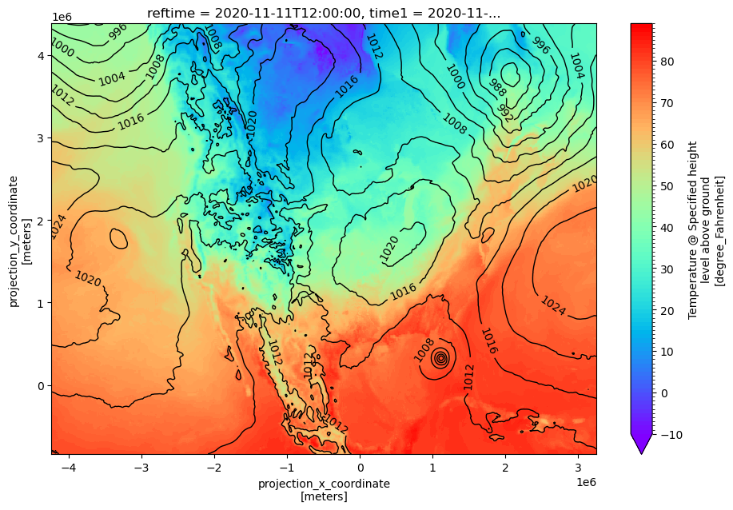

```python
###################################################
#
# Quick Plot
#

# pre-set your own plotting levels

t2m_degF_levels = np.arange(start =  -10,
                            stop  =   90,
                            step  =    1)

mslp_hPa_levels = np.arange(start =  800,
                            stop  = 1040,
                            step  =    4)

# make me bigger than the default.

plt.rcParams['figure.figsize'] = (11, 7)

# make a simple plot of the array using imshow's raster plot option.

imshowplot  = t2m_degF.plot.imshow( cmap       = plt.cm.rainbow,
                                    levels     = t2m_degF_levels)

contourplot = mslp_hPa.plot.contour(colors     = "black",
                                    levels     = mslp_hPa_levels,
                                    linewidths = 1)


plt.clabel(contourplot,
           contourplot.levels,
           fmt='%d')

plt.show()

#
###################################################
```

Unless the data is already in geographic coordiantes (or as Cartopy says "Platte Carrée", the x- and y-axes will not be in latitude and longitude.

Otherwise, while the above plot still looks nice, the only spatial orientation the average human has as to where we are is the impact that land-sea and terrain differences have on 2-m air temperature. For the rest of us, here is where those projections come to play! The center point (where both the eastings and northings are zero) are 0 in this dataset are at the declared center of the projection.

Let's take a peak again at that "crs" field. This time using metpy resources (that, in turn, source resources in cartopy)

```python
###################################################
#
# let's peek at the crs through metpy's cartopy's interface
#

data_crs = ds.metpy_crs.metpy.cartopy_crs

print("Displaying ds.metpy_crs.metpy.cartopy_crs as a proj4 string")
display(data_crs.proj4_init)

print("Displaying ds.metpy_crs.metpy.cartopy_crs as a generic map")
display(data_crs)

#
###################################################
```

```
Displaying ds.metpy_crs.metpy.cartopy_crs as a proj4 string
```

```
'+ellps=sphere +a=6371229.0 +b=6371229.0 +proj=lcc +lon_0=265.0 +lat_0=25.0 +x_0=0.0 +y_0=0.0 +lat_1=25.0 +no_defs'
```

```
Displaying ds.metpy_crs.metpy.cartopy_crs as a generic map
```

[figure not shown]

```
<cartopy.crs.LambertConformal object at 0x29a6a3700>
```

The projection information doesn't have the bounds we need -- but that's what the northings and eastings are for.

### Integrating the Cartopy Projection with MetPy's Eastings and Northings

MathplotLib can access [geographic projection information](https://matplotlib.org/3.2.1/api/projections_api.html). We only need to merge projection with the eastings and northings. We can do this with the cartopy_crs data.

Doing this on your own, just do one line at a time to see how this comes together.

Basically each step builds on the other until you drop the image with plot.show()

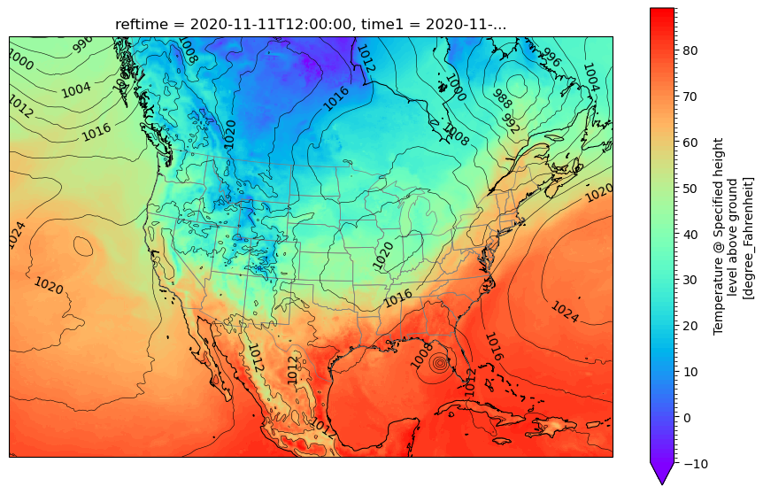

```python
###################################################
#
# Integrating a projection data to our image data.
#

# make a figure space

fig = plt.figure(figsize=(11, 7))

# add a plot element just one field

                   # nrows, ncols, index [which oddly starts with one (go fig)],
ax = fig.add_subplot(    1,     1,     1,
                     projection = data_crs)

# of you use the coastlines and add_feature you can see it does
#   the full cone and our place on it


ax.coastlines(resolution = 'auto',linewidths =  0.75)


ax.add_feature(cfeature.STATES.with_scale('110m'),
                   linewidths = 0.5,
                   facecolor  = 'none',
                   edgecolor  = 'tab:gray')

#ax.gridlines(draw_labels=True)

# here is our plot from above.

t2m_degF_levels = np.arange(start = -10,
                            stop  =  90,
                            step  =  1)

contourfplot = t2m_degF.plot.imshow(cmap   = plt.cm.rainbow,
                                   levels = t2m_degF_levels)

# and pow this will give us our mapping.

# Let's overlay our pressure contours.

mslp_contour_levels = np.arange(start = 800,
                                stop  = 1040,
                                step  = 4)

contourplot = mslp_hPa.plot.contour(colors     = "black",
                                     linewidths = 0.4,
                                     levels     = mslp_contour_levels)

plt.clabel(contourplot,
           contourplot.levels,
           fmt='%d')


plt.show()

#
###################################################
```

# Version Information

Install the Version_Information tool from GitHub

There was once a very handy tool that would print version information of the Python version, operating system, and the versions of the Python packages you are running.

The developer has moved on to other things but it still has a narrow but ~militant~ ernest fan base (myself included). The original isn't doesn't work with versions of Python above 3.7. So a couple of us wrote some patches to fix it. You can access my version below following these instructions.

1. You can pip it in using the following command.

```
!pip install version_information
```

```python
################################################################
#
# Loading Version Information
#
# You need git for this.

#

%load_ext version_information
%version_information version_information, numpy, metpy, matplotlib, cartopy

#
################################################################
```

```
The version_information extension is already loaded. To reload it, use:
  %reload_ext version_information
```

| Software | Version |
| --- | --- |
| Python | 3.10.10 64bit [Clang 14.0.6 ] |
| IPython | 8.12.0 |
| OS | macOS 13.3.1 arm64 arm 64bit |
| version_information | 1.0.4 |
| numpy | 1.24.2 |
| metpy | 1.4.1 |
| matplotlib | 3.7.1 |
| cartopy | 0.21.1 |
| Fri Apr 28 21:13:07 2023 MDT |  |